# *Estimating Probilities With Python*

##### Source Material Website: https://www.dataquest.io

[figure not shown]

**In this first notebook on probability you will learn:**

- **How to calculate empirical probabilities.**
- **How to calculate theoretical probabilities.**
- **The difference between events and outcomes.**

# **Dependencies**

```python
from numpy.random import seed, randint
from matplotlib import pyplot as plt

# This line of code sets the style of plots for Matplotlib
# The types of styles allowed can be found at: https://matplotlib.org/3.1.1/gallery/style_sheets/style_sheets_reference.html
plt.style.use('bmh')

# This line of code is to set a random seed for reproducibility.
seed(1)
```

# *Empirical (Experimental) Probability*

Generally, for any event "E" (like a coin landing heads up), we can find its probability by using the following formula:

## $P(E) = \frac{Number \: of \: Times \: Event \: (E) \: Happened}{Number \: of \: Times \: The \: Experiment \: is \: Repeated}$

When we calculate the probability of an event by performing an experiment one or more times, we calculate the experimental — or empirical probability — of the event.

### Exercises:

1. Just like in our example above, we tossed a coin 100 times and got heads 56 times. Calculate the probability of getting tails using the formula above and assign the result to p_tail.
2. We rolled a regular six-sided die 200 times and:
   - We got a six 28 times. Calculate the probability of getting a 6 when rolling a six-sided die. Assign the result to p_six.
   - We got an odd number (a 1, a 3, or a 5) 102 times. Calculate the probability of getting an odd number when rolling a six-sided die. Assign the result to p_odd.
3. Print p_tail, p_six, and p_odd to examine the probabilities.

```python
#1.)

p_tail = (100-56)/100

#2.)

p_six = 28/200

p_odd = 102/200

#3.)

print(f'#1 P(E)={p_tail}, #2 P(E)={p_six} and P(E)={p_odd}')
```

```
#1 P(E)=0.44, #2 P(E)=0.14 and P(E)=0.51
```

# **Converting Proportions to Percentages**

Notice that the answers above represents a proportion. We can convert proportions to percentages like so:

### $P(E)=0.44=44\%$

This tells us that the empirical probability of an event is nothing but the relative frequency (proportion or percentage) of that event with respect to the total number of times the experiment was performed. Using percentages gives us a more intuitive understanding of what a probability value really is.

### Exercises:

1. We tossed a coin 300 times and got tails 162 times.
   - Find the probability of getting heads. Assign your result to p_heads_1.
   - Transform the probability in p_heads_1 to a percentage value. Assign the result to percentage_1.
2. In a different trial, we tossed a coin 5,000 times and got tails 2,450 times.
   - Find the probability of getting heads. Assign your result to p_heads_2.
   - Transform the probability in p_heads_2 to a percentage value. Assign the result to percentage_2.

```python
#1.)

p_heads_1 = (300-162)/300

percentage_1 = 100 * p_heads_1

#2.)

p_heads_2 = (5000-2450)/5000

percentage_2 = 100 * p_heads_2

print(f'#1 is {percentage_1}% and #2 is {percentage_2}%')
```

```
#1 is 46.0% and #2 is 51.0%
```

# **P(H) Tends to Approach The True Value**

In the previous exercise, we tossed a coin 300 times, and found that $P(H)=46\%$. Then, we tossed a coin 5,000 times and found that $P(H)=51\%$. But if different number of tosses give different probability values, then what's the true value of P(H)? To answer this question, we're going to do a thought experiment where we assume we already know that the true probability of P(H) is 50%. We'll also assume the chances are the same for getting tails, so (P(T) is an abbreviation for P(Tails)). Using these assumptions, we're going to use **Python** to simulate a coin toss 10,000 times and watch how P(H) evolves as the number of tosses increases. We begin by writing a function named coin_toss() that can simulate a single coin toss:

```python
# Single coin toss function
def coin_toss():
    if randint(0,2) == 1:
        return 'HEAD'
    else:
        return 'TAIL'
```

In the code above:

- We used the seed() function to set a random seed for reproducibility.
- We used the randint(0, 2) function to generate randomly either a 0 or a 1 (2 won't be included). Because randint() generates numbers randomly, there's a 50% chance to get a 0 and 50% chance to get a 1 — this helps us introduce in our code a logic for P(H)=50% and P(T)=50%.
- If randint(0, 2) returns 1, our coin_toss() function returns 'HEAD', otherwise it returns 'TAIL'.

Now let's repeat the experiment 10,000 times in the exercise below. We'll analyze the results using a line plot and see how P(H) evolves as the number of tosses increases. Remember that the point of this experiment is to help us understand the true value of P(H).

```python
# Creating a loop to simulate 10,000 coin toses

# List to store calculated probabilites
probabilities = []

# Initiate heads count at 0
heads = 0

for n in range(1, 10001):
    outcome = coin_toss()
    if outcome == 'HEAD':
        heads += 1
    current_probability = heads / n
    probabilities.append(current_probability)

# Print first 10 and last ten probabilities calculated
print(probabilities[:10])
print(probabilities[-10:])
```

```
[1.0, 1.0, 0.6666666666666666, 0.5, 0.6, 0.6666666666666666, 0.7142857142857143, 0.75, 0.7777777777777778, 0.7]
[0.4993494144730257, 0.49939951961569257, 0.4993495446812769, 0.4993996397838703, 0.4993496748374187, 0.4992997198879552, 0.49934980494148246, 0.4993998799759952, 0.49934993499349933, 0.4994]
```

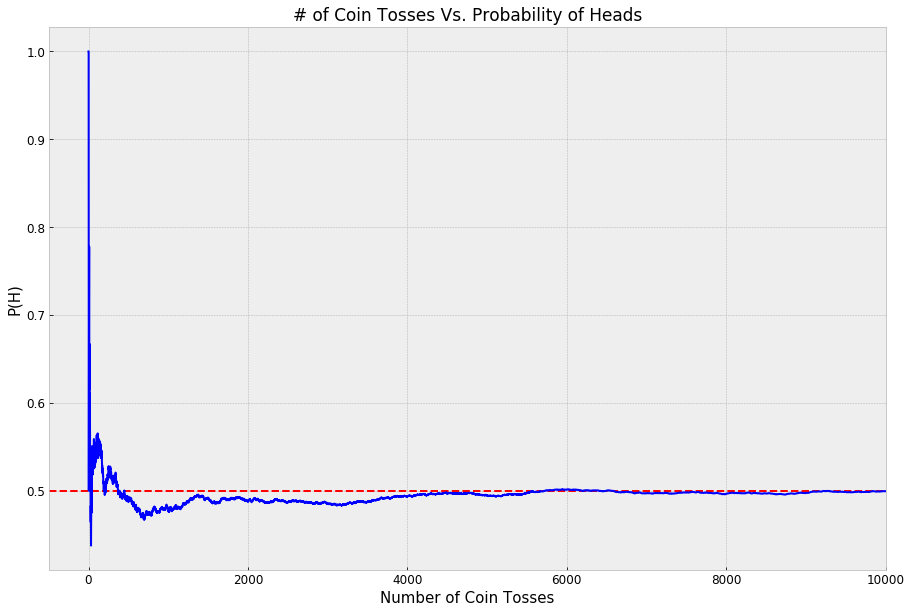

```python
# Creating a plot to represent our tosses vs. probability

# Plot size
plt.figure(figsize = (15, 10))

# Creates dashed line
plt.axhline(y = 0.5, color = 'red', ls='--')

# Plot settings
plt.xticks(fontsize = 12)
plt.yticks(fontsize = 12)
plt.xlim(-500,10000)
plt.xlabel('Number of Coin Tosses', fontsize = 15)
plt.ylabel('P(H)', fontsize = 15)
plt.title('# of Coin Tosses Vs. Probability of Heads', fontsize = 17)

# Creates plot
plt.plot(range(0,10000),probabilities, color = 'blue')
```

Above, we see that for the first 1,000 tosses or so, the value of P(H) varies a lot, with a maximum of 1.0 and a minimum of approximately 0.45. However, as the number of tosses increases, the value of P(H) tends to stabilize. Interestingly enough, P(H) stabilizes around the true value of P(H), which we assumed to be P(H)=50%. This suggests that the greater the number of coin tosses, the closer P(H) gets to the true value.

This gives us some insight into our initial question, which was: if different numbers of tosses give different probability values, then what's the true value of P(H)? The true P(H) is given by the relative frequency (expressed as proportion or percentage) of heads as the number of coin tosses increases without bound — the more we repeat the toss, the closer we should be to the true probability.

Generally, the probability of an event (a coin landing heads up, getting a 5 when we roll a die, etc.) approaches the true probability value as the number of trials of the random experiment (a coin toss, the rolling of a die, etc.) increases without bound.

So far, we've only focused on empirical probabilities. On the next screen, we'll look at a different technique to estimate probabilities — a technique you might be more familiar with.

# *Theoretical Probability*

So far, we learned we need to perform an experiment to estimate probability values. We also said that a probability value estimated by performing an experiment is called empirical (or experimental) probability. To find the empirical probability of any event "E" (like a coin landing heads up), we learned to use the formula:

## $P(E) = \frac{Number \: of \: Times \: Event \: (E) \: Happened}{Number \: of \: Times \: The \: Experiment \: is \: Repeated}$

However, properly calculating empirical probabilities requires us to perform a random experiment many times, which may not always be feasible in practice. An easier way to estimate probabilities is to start with the assumption that the outcomes of a random experiment have **equal chances of occurring**. This allows us to use the following formula to calculate the probability of an event "E":

## $P(E) = \frac{1}{Total \: Number \: of \: Possible \: Outcomes}$

For instance, the total number of possible outcomes for a coin toss is two: heads or tails. Let "H" be the event that a coin lands on heads, and "T" the event that a coin lands on tails. We can use the formula above to find P(H) and P(T):

$P(H)=\frac{1}{2}=0.5$

$P(T)=\frac{1}{2}=0.5$

Let's also consider the rolling of a die, where there are six possible outcomes: 1, 2, 3, 4, 5 or 6. Assuming each outcome has the same chance of occurring, the probability of getting a 2 or a 4 is:

$P(2)=\frac{1}{6} \approx 0.167$

$P(4)=\frac{1}{6} \approx 0.167%$

When we calculate the probability of an event under the assumption that the outcomes have equal chances of occurring, we say that we're calculating the **theoretical probability** of an event.

Theoretical probabilities are much easier to calculate, but in practice it doesn't always make sense to assume the outcomes of a random experiment have equal chances of occurring. If you were playing the lottery, it wouldn't be reasonable to assume that the two possible outcomes (you win or you don't) have equal chances.

If you were a scientist trying to calculate the probability of a human becoming infected with the HIV virus, it wouldn't be reasonable to assume the two possible outcomes (becoming infected with HIV or not) have equal chances of occurring. Both theoretical and empirical probabilities are helpful and important in practice.

### Exercises:

Next, we'll discuss some important exceptions to the new formula we introduced above. First, let's practice calculating theoretical probabilities. For the exercises below, assume that all outcomes have equal chances of occurring.

1. Find the theoretical probability of getting a 5 when rolling a six-sided die. Assign your answer to p_5.
2. Tossing a coin twice has four possible outcomes (assume all the outcomes are equally likely):
   - Heads on the first toss and heads on the second toss (HH).
   - Heads on the first toss and tails on the second (HT).
   - Tails on the first toss and heads on the second (TH).
   - Tails on the first toss and tails on the second (TT).
3. Find:
   - P(HT): Assign your result to p_ht.
   - P(TT): Assign your result to p_tt.

```python
#1.)
p_5 = 1/6

#2.)
p_ht = 1/4

p_tt = 1/4
```

# **Event Vs. Outcome**

So far, we've repeatedly used the terms "event" and "outcome," and we need to add a few clarifications. An outcome is any result that a random experiment may terminate in. For instance, all the possible outcomes of rolling a six-sided die are 1, 2, 3, 4, 5, and 6. An event, however, has a richer meaning and can include more than one outcome (or even zero outcomes):

- The event that we'll get an odd number when we roll a six-sided die — this event includes the outcomes 1, 3, and 5.
- The event that we'll get a number less than 5 but greater than 1 when we roll a six-sided die — this event includes the outcomes 2, 3, and 4.
- The event that we'll get a number greater than 20 when we roll a six-sided die — this event doesn't include any of the possible outcomes corresponding to rolling a six-sided die.

Although an event can include a single outcome (like the event of getting a 2 when we roll a die), the two concepts still have a different meaning. We always assign probabilities to events, not outcomes, even if the event includes only one outcome.

Above, we learned we can use this formula to compute the theoretical probability of an event:

## $P(E) = \frac{1}{Total \: Number \: of \: Possible \: Outcomes}$

However, we can't use this formula to compute theoretical probabilities for events that include more than one outcome. Take the event that we'll get any number between 1 and 6 (both included) when rolling a six-sided die. The outcomes are 1, 2, 3, 4, 5, and 6, so there are 100% chances we'll get some number between 1 and 6. Using our formula, however, we find the probability is approx. 16.7% :

$P(number\: between\: 1\: and\: 6)\approx 0.167 \approx 16.7\%$

To fix this problem, we need to update the formula above to:

## $P(E) = \frac{Number \: of \: Successful \: Outcomes}{Total\: Number \: of \: Possible \: Outcomes}$

The "number of successful outcomes" part represents the number of outcomes included in the event "E", and "total number of possible outcomes" is the number of possible outcomes that the random experiment associated with the event "E" could terminate in.

The event that we'll get an odd number when we roll a six-sided die includes three successful outcomes (1, 3, and 5), and the random experiment of rolling the die includes six possible outcomes (1, 2, 3, 4, 5, and 6). This means:

#### $P(odd\: number) = \frac{Number \: of \: Successful \: Outcomes}{Total\: Number \: of \: Possible \: Outcomes} = \frac{3}{6} = 0.5 = 50\%$

Using the updated formula, we also find that the probability of getting a number between 1 and 6 when we roll a die is 100%, just like we'd intuitively expect:

#### $P(number\:between\: 1\: and\: 6) = \frac{Number \: of \: Successful \: Outcomes}{Total\: Number \: of \: Possible \: Outcomes} = \frac{6}{6} = 1 = 100\%$

# **A Tale of Caution: Outcomes Not Having Equal Chances**

Above, we came to the conclusion that we can use this formula to compute theoretical probabilities:

## $P(E) = \frac{Number \: of \: Successful \: Outcomes}{Total\: Number \: of \: Possible \: Outcomes}$

However, let's say we have a biased six-sided die which has a 6 on three of its sides, and 1, 3, and 5 on the rest of the sides.

[figure not shown]

To be able to use the formula above, we need to take into account that 6 shows up on three sides. To do that, we treat each 6 as a different outcome and say that for this biased die the possible outcomes are 1, 3, 5, 6, 6 and 6.

Since we treat each 6 as a different outcome, the event "getting a 6" has three successful outcomes: 6, 6 and 6. This means that the probability of getting a 6 is:

#### $P(6) = \frac{Number \: of \: Successful \: Outcomes}{Total\: Number \: of \: Possible \: Outcomes} = \frac{3}{6} = 0.5 = 50\%$

The event "getting a 3" has only one successful outcome, and the event "getting a 2" has no successful outcome, which leads to:

#### $P(3) = \frac{Number \: of \: Successful \: Outcomes}{Total\: Number \: of \: Possible \: Outcomes} = \frac{1}{6} \approx 0.167 \approx 16.7\%$

#### $P(2) = \frac{Number \: of \: Successful \: Outcomes}{Total\: Number \: of \: Possible \: Outcomes} = \frac{0}{6} = 0$

If we didn't treat each 6 differently and said it doesn't matter which side a 6 is on, we'd be forced to conclude the only possible outcomes are 1, 3, 5 and 6. We can definitely frame the problem like that, but the formula above won't work anymore — we see below P(6) becomes the same as P(3), but, intuitively, P(6) should be higher than P(3) since the die has 6 on three of its sides:

#### $P(3) = \frac{Number \: of \: Successful \: Outcomes}{Total\: Number \: of \: Possible \: Outcomes} = \frac{1}{4} =0.25 = 25\%$

#### $P(6) = \frac{Number \: of \: Successful \: Outcomes}{Total\: Number \: of \: Possible \: Outcomes} = \frac{1}{4} =0.25 = 25\%\:(wrong)$

The formula doesn't work anymore because the assumption of equally likely outcomes is violated — in this case, 6 has more chances of occurring than the other outcomes.

**The take-home message here is that the formula above works under the assumption that the outcomes have equal chances of occuring. If the assumption is violated, the formula will output wrong probability values.**

# *Core Concepts of This Notebook:*

- A random experiment is any process for which we can't predict outcomes with certainty. Examples of random experiments include: the toss of a coin and the rolling of a die.
- When we calculate the probability of an event by performing an experiment, we calculate the experimental — or empirical probability — of the event.
- Generally, for any event "E" (like a coin landing heads up), we can find its empirical probability by using the following formula:

  ## $P(E) = \frac{Number \: of \: Times \: Event \: (E) \: Happened}{Number \: of \: Times \: The \: Experiment \: is \: Repeated}$
- Generally, the empirical probability of an event (a coin landing heads up, getting a 5 when we roll a die) approaches the true probability value as the number of trials of the random experiment (a coin toss, the rolling of a die) increases without bound.
- When we calculate the probability of an event under the assumption that the outcomes have equal chances of occurring, we say that we're calculating the theoretical probability of an event.
- Generally, for any event "E", we can find its theoretical probability by using the following formula:

  ## $P(E) = \frac{Number \: of \: Successful \: Outcomes}{Total\: Number \: of \: Possible \: Outcomes}$
- The theoretical probability formula only works as long as the assumption of outcomes having equal chances of occurring is reasonable. When the assumption is violated, we can still compute theoretical probabilities by transforming the problem into a proportion problem.